# IODS course project

Susanna Suntila

# Introduction to Open Data Science - Course Project

# About the project

*This course - Introduction to Open Data Science - makes use of the open research tools with open data and how to apply data-driven statistics.*

*Link to my project: https://github.com/SusannaSuntila/IODS-project*

```r
date()
```

```
## [1] "Mon Nov 21 13:53:05 2022"
```

## Thoughts about the course

I am excited and I only hope that I can keep up with the pace and content of this course, but it all sounds very interesting. I have taken some courses in R, but I have not used it professionally or for that long. I want to become even more familiar in using R and I want to deepen my skills in visualizing, sharing, wrangling, testing and analyzing data. I heard about this course in my previous course for research skills.

## Learning experience with the R book and Exercise set 1

- The first exercise was a good introduction, as I was already a bit familiar with the book, but now I could focus on the parts that were more difficult for me, or that I hadn’t really used before.
- Some more simple functions, like filter() or group_by() are something that I will try to make use of even more.
- In my last R-course I was introduced to **ggplot**, and drawing plots and fine-tuning them was definitely my favorite part of this exercise. I hope to develop my skills on that score during this course.
- Working with **factors** was also part of the book that I liked, and there were functions that I hadn’t used, like summary_factorlist.
- I haven’t really used the tidy() function to tidy up the results of a statistical tests, so reading these chapters was good reminder of that option as well.
- I haven’t done any reshaping of data with regards to the format, especially **tidying from a wide to a long format**. That was a more difficult part of the book for me, but it is definitely something I want to practice.
- Different statistical tests and plotting data in order to choose the right test was also a more demanding part for me and something that I want to focus on during this course.
- Many of the functions and approaches used from the **finalfit-package** were more difficult as well, as I haven’t used much of those.
- I like the so called active reading, as it helps to understand better what is happening and also enables to try some changes to the code myself. I think the book is clear and well constructed.
- I have a lot to learn about using R-markdown, so this has been a good start. There has been quite a lot of new concepts in the first week.

# Regression and model validation

```r
date()
```

```
## [1] "Mon Nov 21 13:53:05 2022"
```

## Read in the data and describe it

```r
library(tidyverse)
# the data-set that I created
learning2014 <- read.csv(file.path(".", "data", "learning2014.csv"))
```

```r
# Look at the dimensions of the data
dim(learning2014)
```

```
## [1] 166   7
```

```r
# Look at the structure of the data
str(learning2014)
```

```
## 'data.frame':    166 obs. of  7 variables:
##  $ gender  : chr  "F" "M" "F" "M" ...
##  $ age     : int  53 55 49 53 49 38 50 37 37 42 ...
##  $ attitude: num  3.7 3.1 2.5 3.5 3.7 3.8 3.5 2.9 3.8 2.1 ...
##  $ deep    : num  3.58 2.92 3.5 3.5 3.67 ...
##  $ stra    : num  3.38 2.75 3.62 3.12 3.62 ...
##  $ surf    : num  2.58 3.17 2.25 2.25 2.83 ...
##  $ points  : int  25 12 24 10 22 21 21 31 24 26 ...
```

There are 166 rows (observations) and 7 columns (variables) in this data. The gender variable is a character, the other variables are numbers or integers.

The original data is from a questionnaire that tracked different learning approaches and achievements on an introductory statistical course at university level. Gender and age are self-explanatory. The points variable tells how many exam points the person had. The attitude variable is a sum of 10 questions related to student’s attitude towards statistics, in a 1-5 scale. The remaining variables deep, stra and surf are combination variables that have been combined from multiple questions with the same dimension. The variables are averages of the selected questions concerning deep, surface and strategic learning.

## Graphical overview of the data and summaries of the variables

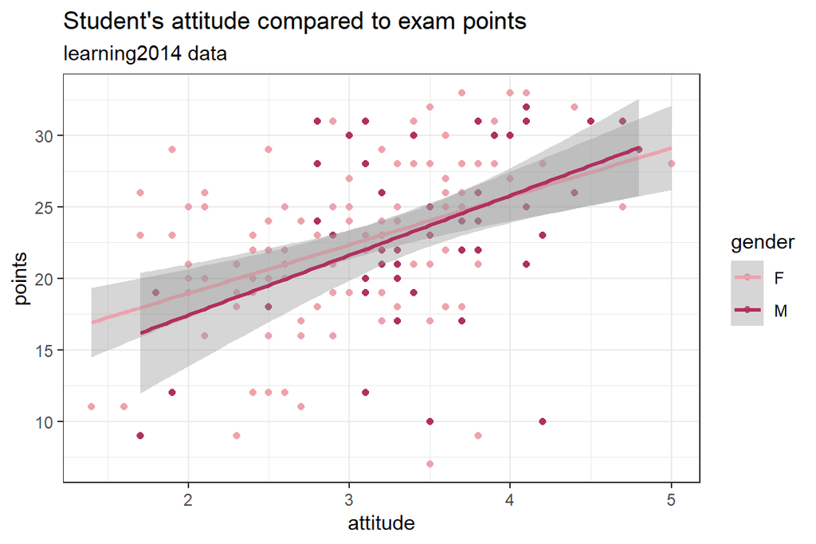

```r
library(ggplot2)

# set the theme white
theme_set(theme_bw())


# plot of student's attitude and points
ggplot(learning2014, aes(x = attitude, y = points, col = gender)) +
  geom_point() +
  geom_smooth(method = "lm") +
  scale_colour_manual(values = c("lightpink2", "maroon")) +
  labs(title = "Student's attitude compared to exam points",
       subtitle =  "learning2014 data")
```

```r
library(GGally)
```

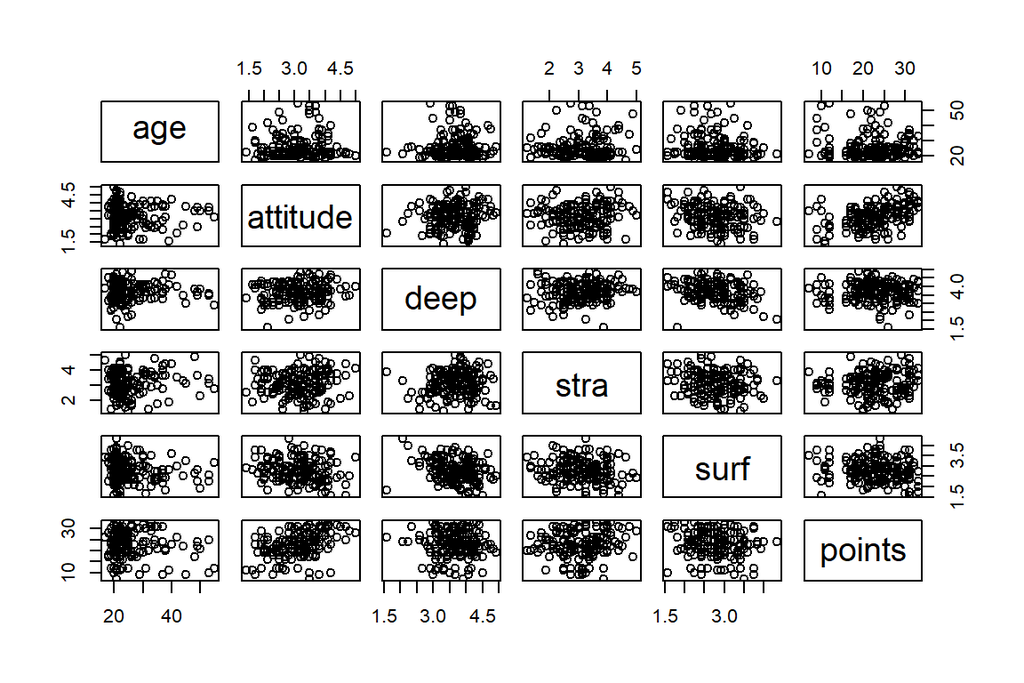

```r
library(ggplot2)

# draw a scatter plot matrix of the variables in learning2014.
# [-1] excludes the first column (gender)
pairs(learning2014[-1])
```

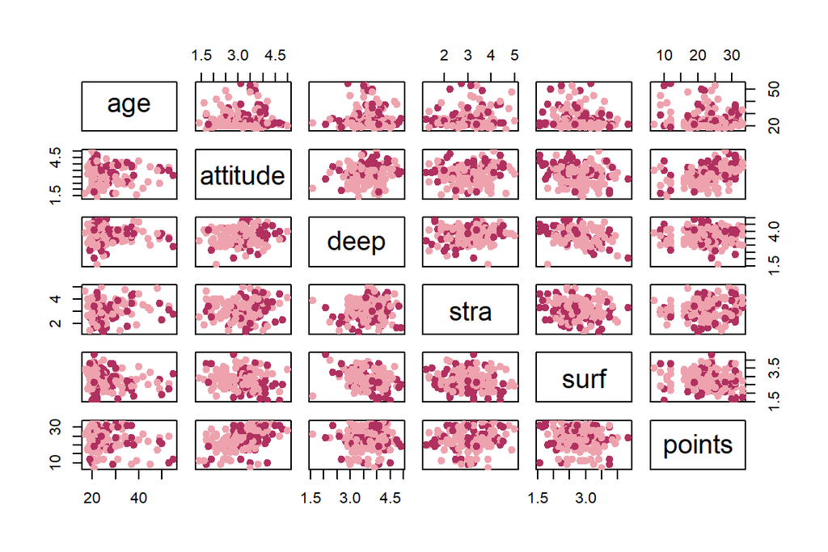

```r
# add color by gender
gender_col <- c("lightpink2", "maroon")[unclass(factor(learning2014$gender))]

pairs(learning2014[-1], pch = 19, col = gender_col)
```

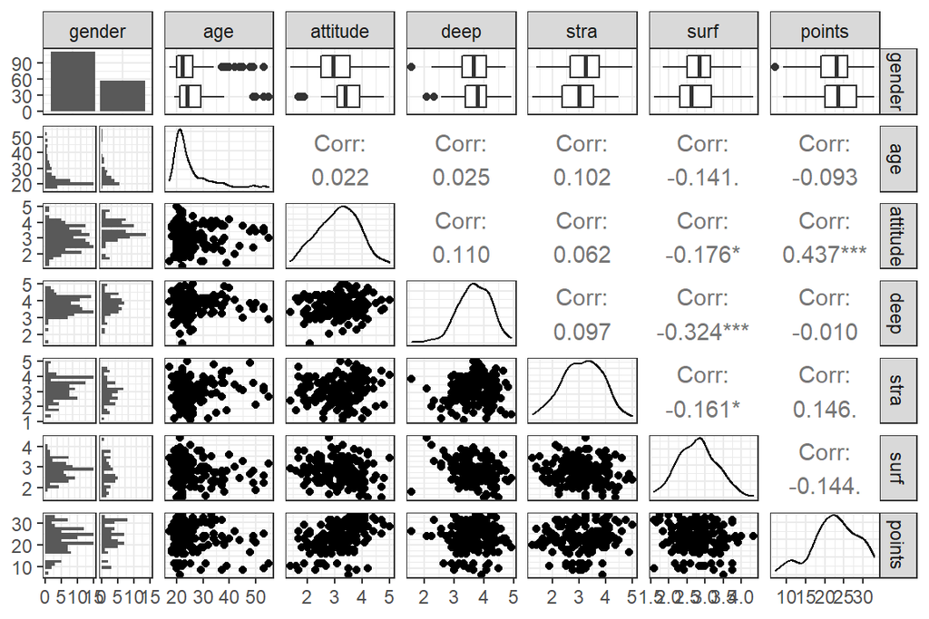

```r
# create a more advanced plot matrix with ggpairs()
ggpairs(learning2014, mapping = aes(), lower = list(combo = wrap("facethist", bins = 20)))
```

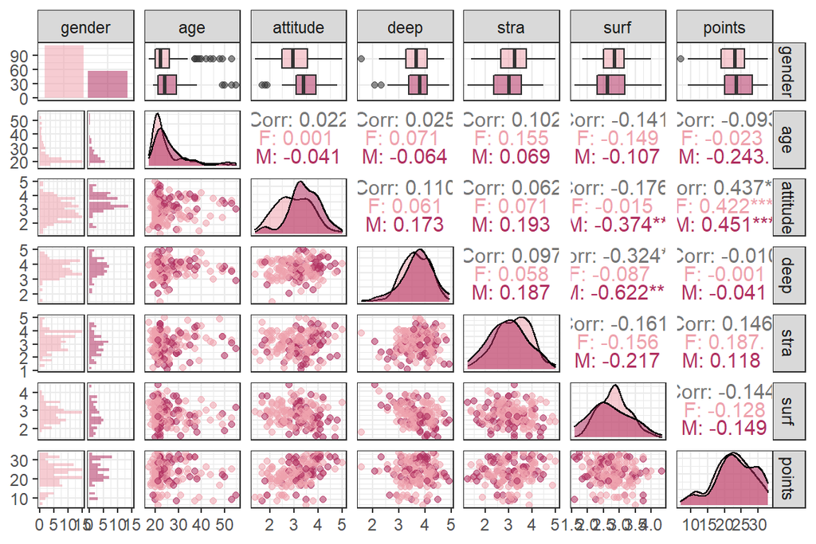

```r
# with color by gender
ggpairs(learning2014, mapping = aes(col = gender, alpha = 0.3), lower = list(combo = wrap("facethist", bins = 20))) +
  scale_colour_manual(values = c("lightpink2", "maroon")) +
  scale_fill_manual(values = c("lightpink2", "maroon"))
```

First, there are clearly more women who have participated in this questionnaire than men. When looking at the distribution of the variables, it is clear that age is concentrated below thirty, with a long tail towards right. With the age variable, the skew is larger than with any other variable. There is also more variation between men compared to women. Interestingly with the attitude variable, there is more variation with women compared to men. Men also have slightly higher mean, and their distribution is more skewed. The deep variable has a longer tail on the left side, so the observations are more concentrated on the higher side. The difference between genders is very small in this case. The stra variable has a wide distribution. The surf variable is more concentrated among women compared to men. The point variable has a thick tale among lower scores and the distribution is more concentrated among higher scores.

The largest and most significant correlation can be found with attitude and points. It is positive, so better attitude is related to better points in the exam. The lowest correlation is between deep learning and points from the exam which is interesting as well. Surf variable is also significantly correlating with attitude and deep.

## Regression model with three explanatory variables

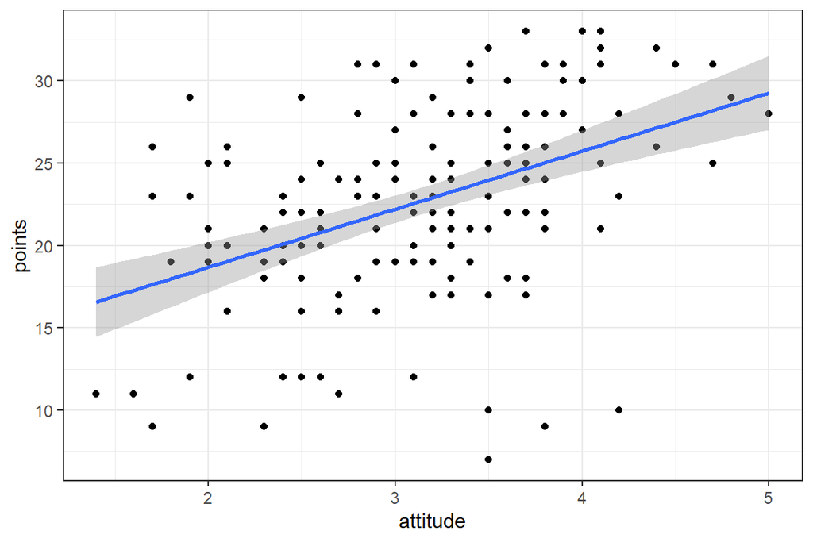

```r
library(GGally)
library(ggplot2)

# draw a plot of the linear relation of exam points and attitude
qplot(attitude, points, data = learning2014) + geom_smooth(method = "lm")
```

```r
# create a regression model with multiple explanatory variables
model1 <- lm(points ~ attitude + gender + stra, data = learning2014)

# print out a summary of the model
summary(model1)
```

```
##
## Call:
## lm(formula = points ~ attitude + gender + stra, data = learning2014)
##
## Residuals:
##      Min       1Q   Median       3Q      Max
## -17.7179  -3.3285   0.5343   3.7412  10.9007
##
## Coefficients:
##             Estimate Std. Error t value Pr(>|t|)
## (Intercept)   8.9798     2.4030   3.737 0.000258 ***
## attitude      3.5100     0.5956   5.893 2.13e-08 ***
## genderM      -0.2236     0.9248  -0.242 0.809231
## stra          0.8911     0.5441   1.638 0.103419
## ---
## Signif. codes:  0 '***' 0.001 '**' 0.01 '*' 0.05 '.' 0.1 ' ' 1
##
## Residual standard error: 5.304 on 162 degrees of freedom
## Multiple R-squared:  0.2051, Adjusted R-squared:  0.1904
## F-statistic: 13.93 on 3 and 162 DF,  p-value: 3.982e-08
```

In this model the dependent variable is exam points as instructed. The three explanatory variables that I chose are attitude, gender and stra. In the summary of the model it can be seen that only the intercept and the variable attitude are statistically significant, so attitude is the only variable strongly associated with exam points in this particular model. The coefficient on attitude, 3.5, tells that one unit change in attitude is related to a 3.5 point increase in exam points, conditional on other variables of this model. The gender variable is a dummy variable that has the value 1 when the person’s gender is male, so the coefficient of the gender variable describes the difference between the two genders, and when the person is male, it lowers the exam points by -0.22, again conditional on the other variables of this model. The stra variable that is computed from strategic questions has a coefficient of 0.89, meaning that better strategic learning will increase the exam points. The F-test that all three coefficients would be zero has a very small p-value, so it can be rejected.

As the variables gender and stra were not statistically significant, I dropped the gender variable first in the next model.

```r
# create a second regression model
model2 <- lm(points ~ attitude + stra, data = learning2014)

# print out a summary of the model
summary(model2)
```

```
##
## Call:
## lm(formula = points ~ attitude + stra, data = learning2014)
##
## Residuals:
##      Min       1Q   Median       3Q      Max
## -17.6436  -3.3113   0.5575   3.7928  10.9295
##
## Coefficients:
##             Estimate Std. Error t value Pr(>|t|)
## (Intercept)   8.9729     2.3959   3.745  0.00025 ***
## attitude      3.4658     0.5652   6.132 6.31e-09 ***
## stra          0.9137     0.5345   1.709  0.08927 .
## ---
## Signif. codes:  0 '***' 0.001 '**' 0.01 '*' 0.05 '.' 0.1 ' ' 1
##
## Residual standard error: 5.289 on 163 degrees of freedom
## Multiple R-squared:  0.2048, Adjusted R-squared:  0.1951
## F-statistic: 20.99 on 2 and 163 DF,  p-value: 7.734e-09
```

The multiple R-squared is 0.20, which means that the two variables attitude and stra together explain 20 percent of the variation in exam points.

Compared to the last model, the F-statistic has risen as well, and the p-value is smaller.

## Diagnostic plots

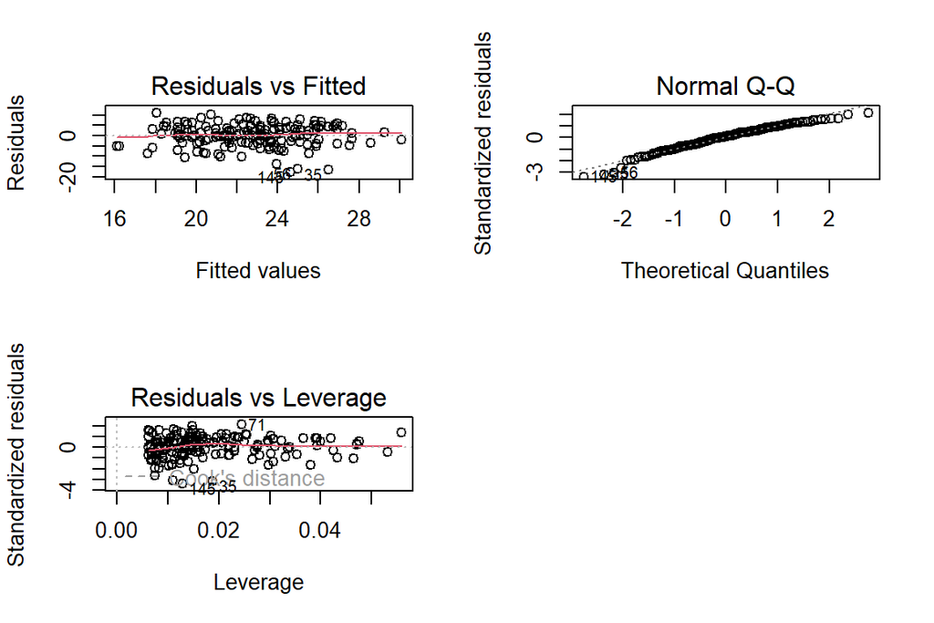

```r
# draw diagnostic plots using the plot() function. Choose the plots 1, 2 and 5
par(mfrow = c(2,2))
plot(model2,which = c(1,2,5))
```

The first plot that compares the residuals with the fitted values shows that the points are spread around quite randomly, except for a few outliers, so the model is pretty appropriate. The plot does not indicate non-linear trends or non-constant variance.

The Q-Q-plot shows that the residuals are somewhat normally distributed. However, the lower tail is more heavy, so the values are larger there than would be expected and the upper tail is lighter, so values are smaller there than expected.

The residuals vs leverage plot shows if there are any outliers that would be significant for the model. The Cook’s distance curved lines don’t show in this plot, so the outliers aren’t too disturbing and there aren’t any points that would have high residuals and too much leverage at the same time.

# Logistic regression

```r
date()
```

```
## [1] "Mon Nov 21 13:53:52 2022"
```

## Read the data

```r
library(tidyverse)
# read in the data that was created
alc <- read.csv(file.path(".", "data", "alc.csv"))

# print names of the variables
colnames(alc)
```

```
##  [1] "school"     "sex"        "age"        "address"    "famsize"
##  [6] "Pstatus"    "Medu"       "Fedu"       "Mjob"       "Fjob"
## [11] "reason"     "guardian"   "traveltime" "studytime"  "schoolsup"
## [16] "famsup"     "activities" "nursery"    "higher"     "internet"
## [21] "romantic"   "famrel"     "freetime"   "goout"      "Dalc"
## [26] "Walc"       "health"     "failures"   "paid"       "absences"
## [31] "G1"         "G2"         "G3"         "alc_use"    "high_use"
```

This data set is constructed from a secondary school student questionnaire of Portuguese schools. As the names of the variables indicate, the questions cover topics such as school and studies, but have also social and demographic aspects. The alc data set is combined from two data sets dealing with the students’ performance in math and Portuguese language.

## Relationships between high/low alcohol consumption

The binary variable **address** is an interesting one, I would predict that when living in urban areas high alcohol use would be more probable, as there are more options to use alcohol than for students living in rural areas.

Another variable that I want to look at is the **studytime** one (weekly study time, divided into 4 groups, where 4 is the highest amount spent in studying), to see if spending more time studying is negatively related to high alcohol use, as the student is spending more time with studies and is possibly more committed to school.

I would hypothesize also that **goout** variable, telling how much the student goes out with friends (1-5 scale where 5 is very high) is positively linked to high alcohol use, as alcohol is usually a socially related issue.

Lastly I wanted to include the more continuous variable **absences**, which measures the number of school absences (0-93). I would hypothesize that more absences are positively linked to high alcohol use, as drinking a lot might affect the student’s attendance at school.

## Explore variables’ distributions and relationships with alcohol consumption

First the **address** variable

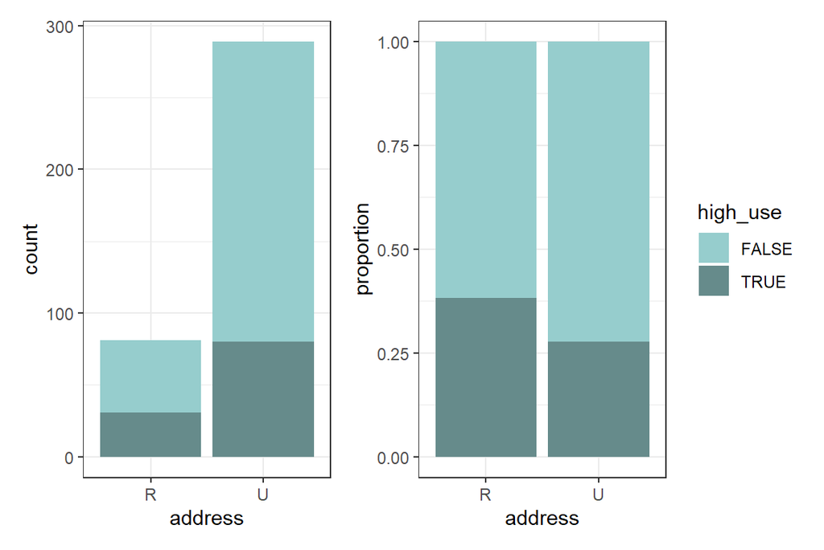

```r
library(ggplot2)

# set the background white
theme_set(theme_bw())

# bar plots of address variable
g1 <-  ggplot(data = alc, aes(x = address, fill = high_use)) +
  geom_bar() +
  theme(legend.position = "none") +
  scale_fill_manual(values = c("paleturquoise3", "paleturquoise4"))

g2 <- ggplot(data = alc, aes(x = address, fill = high_use)) +
  geom_bar(position = "fill") +
  ylab("proportion") +
  scale_fill_manual(values = c("paleturquoise3", "paleturquoise4"))

# combine the two plots
library(patchwork)
g1 | g2
```

As can be expected, most of the students live in urban areas, and so more people have high use of alcohol levels in urban areas, but contrary to what I thought relatively more people have high use of alcohol in rural areas.

Next the **studytime** variable:

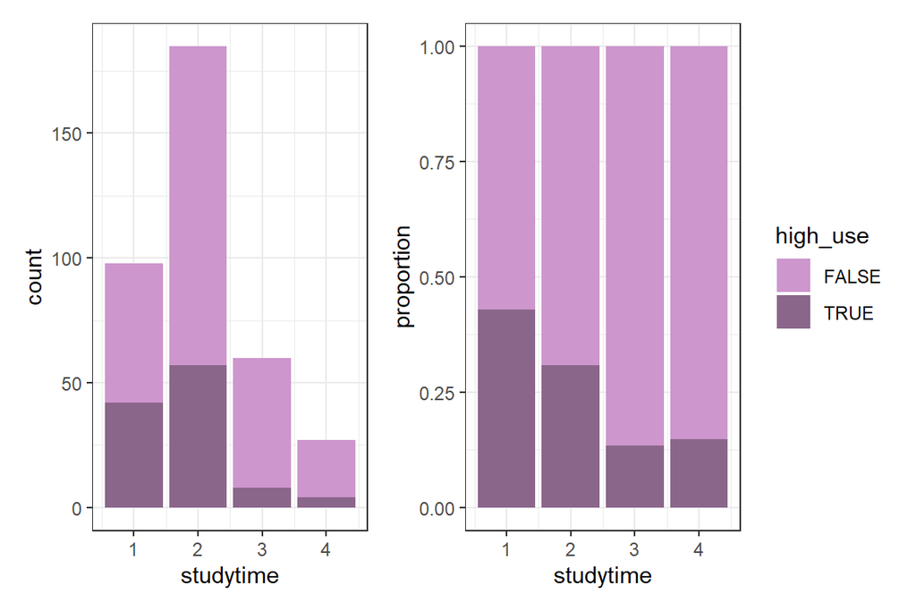

```r
# studytime variable
g3 <-  ggplot(data = alc, aes(x = studytime, fill = high_use)) +
  geom_bar() +
  theme(legend.position = "none") +
  scale_fill_manual(values = c("plum3", "plum4"))

g4 <- ggplot(data = alc, aes(x = studytime, fill = high_use)) +
  geom_bar(position = "fill") +
  ylab("proportion") +
  scale_fill_manual(values = c("plum3", "plum4"))

# combine the two plots
library(patchwork)
g3 | g4
```

Next the **goout** variable:

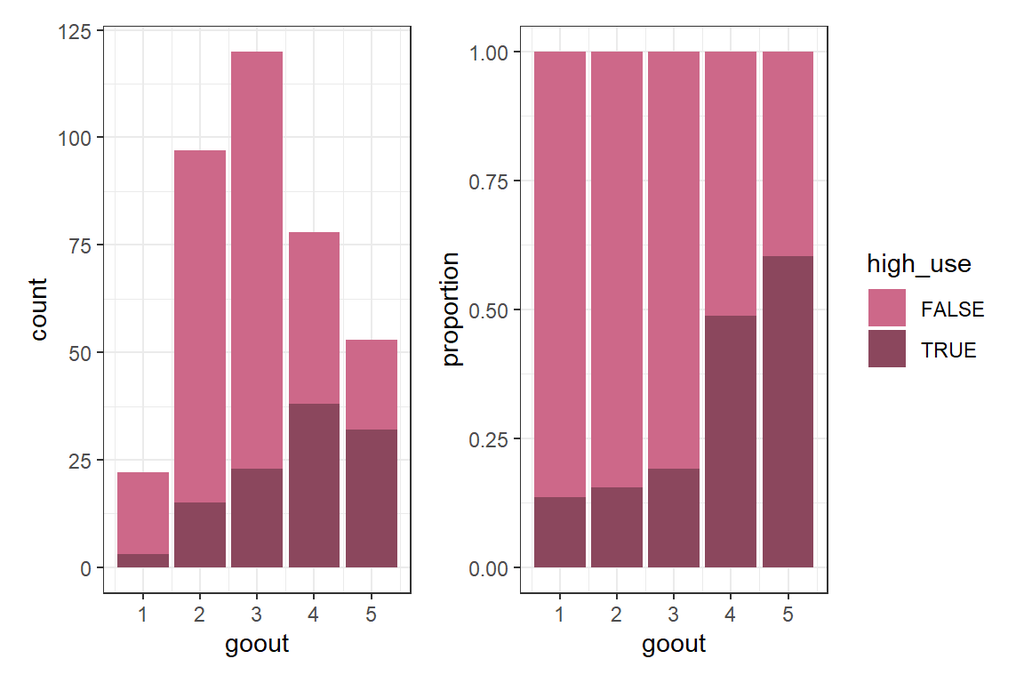

```r
# the going out variable

g5 <-  ggplot(data = alc, aes(x = goout, fill = high_use)) +
  geom_bar() +
  theme(legend.position = "none") +
  scale_fill_manual(values = c("palevioletred3", "palevioletred4"))

g6 <- ggplot(data = alc, aes(x = goout, fill = high_use)) +
  geom_bar(position = "fill") +
  ylab("proportion") +
  scale_fill_manual(values = c("palevioletred3", "palevioletred4"))

# combine the two plots
library(patchwork)
g5 | g6
```

Here the high use of alcohol increases with the amount of going out with friends, and the pattern is very clear.

And lastly the **absences** variable:

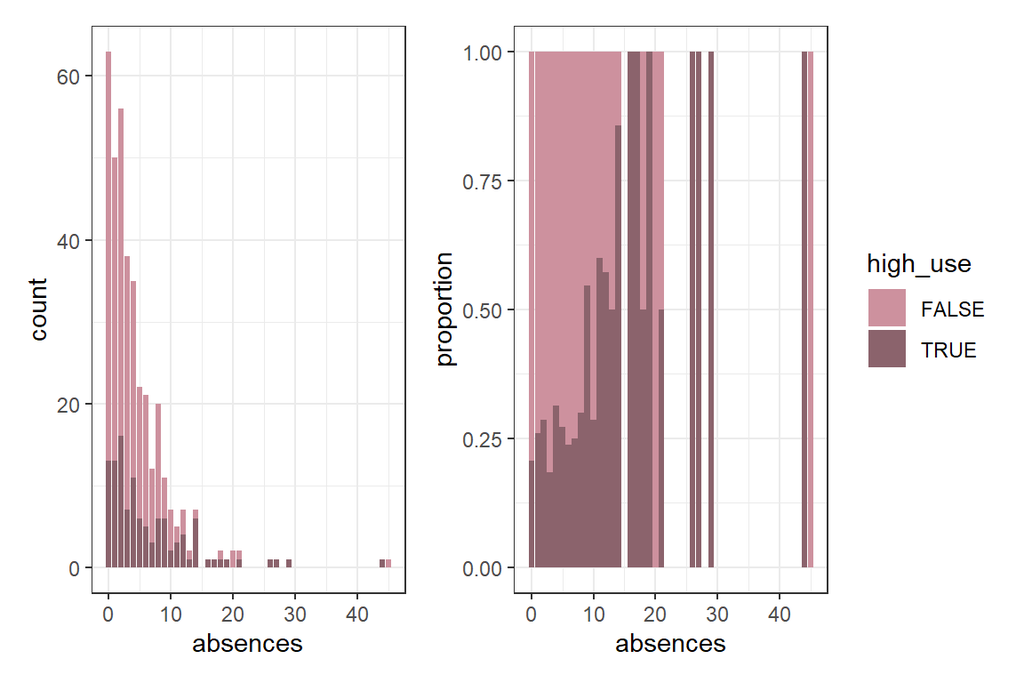

```r
# absences
g7 <- ggplot(data = alc, aes(x = absences, fill = high_use)) +
  geom_bar() +
  theme(legend.position = "none") +
  scale_fill_manual(values = c("pink3", "pink4"))

g8 <- ggplot(data = alc, aes(x = absences, fill = high_use)) +
  geom_bar(position = "fill") +
  scale_fill_manual(values = c("pink3", "pink4")) +
  ylab("proportion")

# combine the two plots
library(patchwork)
g7 | g8
```

Here it is also clear that increase in absences is linked to an increase in high use of alcohol as well, but there are also some outliers with few students who have a very high amount of absences.

Looking at the absences variable closer with a box plot:

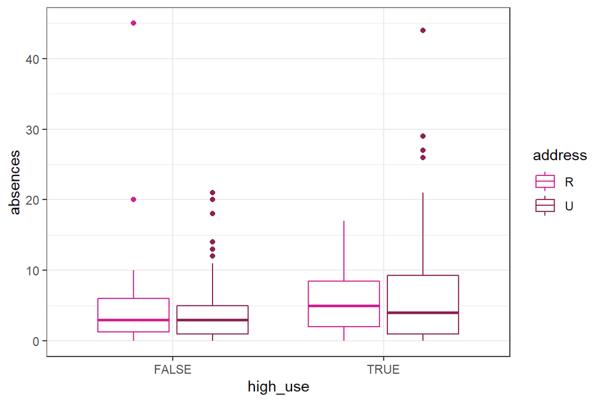

```r
# box plot of absences with color by address
ggplot(data = alc, aes(x = high_use, y = absences, col = address)) +
  geom_boxplot() +
  scale_color_manual(values = c("violetred", "violetred4"))
```

The median of absences is the same whether student is form rural or urban area when there is no high use of alcohol, but the median for absences is slightly higher for students from rural areas if they belong to the high use of alcohol group.

Next few cross-tabulations. First I wanted to add a table that includes address, the mean of going out and of course high use of alcohol.

```r
# table of address, high use of alcohol and the mean of going out
alc %>% group_by(address, high_use) %>% summarise(count = n(), mean_goout = mean(goout))
```

```
## # A tibble: 4 × 4
## # Groups:   address [2]
##   address high_use count mean_goout
##   <chr>   <lgl>    <int>      <dbl>
## 1 R       FALSE       50       2.6
## 2 R       TRUE        31       3.52
## 3 U       FALSE      209       2.91
## 4 U       TRUE        80       3.81
```

The mean of going out increases quite a lot when the alcohol use is high for both rural and urban area students. The mean of going out in both cases of alcohol use is higher for students who live in urban areas compared to rural area students, as would be expected.

Another cross-tabulation of the mean of studytime and mean of absences with regards to alcohol use:

```r
# table of address, high use of alcohol and the mean of going out
alc %>% group_by(high_use) %>% summarise(count = n(), mean_studytime = mean(studytime), mean_absences = mean(absences))
```

```
## # A tibble: 2 × 4
##   high_use count mean_studytime mean_absences
##   <lgl>    <int>          <dbl>         <dbl>
## 1 FALSE      259           2.16          3.71
## 2 TRUE       111           1.77          6.38
```

Those students who have high use of alcohol also have lower mean of studytime and higher mean of absences compared to those who do not have high use of alcohol.

## Logistic regression of the chosen variables

```r
# simple model with only the absences as an explanatory variable
model <- glm(high_use ~ absences, data = alc, family = "binomial")

#summary of the simple model
summary(model)
```

```
##
## Call:
## glm(formula = high_use ~ absences, family = "binomial", data = alc)
##
## Deviance Residuals:
##     Min       1Q   Median       3Q      Max
## -2.3598  -0.8209  -0.7318   1.2658   1.7419
##
## Coefficients:
##             Estimate Std. Error z value Pr(>|z|)
## (Intercept) -1.26945    0.16094  -7.888 3.08e-15 ***
## absences     0.08867    0.02317   3.827  0.00013 ***
## ---
## Signif. codes:  0 '***' 0.001 '**' 0.01 '*' 0.05 '.' 0.1 ' ' 1
##
## (Dispersion parameter for binomial family taken to be 1)
##
##     Null deviance: 452.04  on 369  degrees of freedom
## Residual deviance: 434.52  on 368  degrees of freedom
## AIC: 438.52
##
## Number of Fisher Scoring iterations: 4
```

```r
####

# model with all the chosen variables: absences, studytime, goout and address
model1 <- glm(high_use ~ absences + studytime + goout + address, data = alc, family = "binomial")

# print out a summary of the model
summary(model1)
```

```
##
## Call:
## glm(formula = high_use ~ absences + studytime + goout + address,
##     family = "binomial", data = alc)
##
## Deviance Residuals:
##     Min       1Q   Median       3Q      Max
## -1.9982  -0.7761  -0.4950   0.8461   2.3232
##
## Coefficients:
##             Estimate Std. Error z value Pr(>|z|)
## (Intercept) -1.92997    0.56532  -3.414 0.000640 ***
## absences     0.06687    0.02221   3.011 0.002600 **
## studytime   -0.59099    0.16862  -3.505 0.000457 ***
## goout        0.75392    0.12061   6.251 4.09e-10 ***
## addressU    -0.73038    0.30408  -2.402 0.016308 *
## ---
## Signif. codes:  0 '***' 0.001 '**' 0.01 '*' 0.05 '.' 0.1 ' ' 1
##
## (Dispersion parameter for binomial family taken to be 1)
##
##     Null deviance: 452.04  on 369  degrees of freedom
## Residual deviance: 371.44  on 365  degrees of freedom
## AIC: 381.44
##
## Number of Fisher Scoring iterations: 4
```

```r
# print out the coefficients of the model
coef(model1)
```

```
## (Intercept)    absences   studytime       goout    addressU
## -1.92997318  0.06687033 -0.59099384  0.75391575 -0.73038272
```

```r
# compute odds ratios (OR)
OR <- coef(model1) %>% exp

# compute confidence intervals (CI)
CI <- confint(model1) %>% exp()
# print out the odds ratios with their confidence intervals
cbind(OR, CI)
```

```
##                    OR     2.5 %    97.5 %
## (Intercept) 0.1451521 0.0466309 0.4305313
## absences    1.0691568 1.0250338 1.1197230
## studytime   0.5537766 0.3936409 0.7639234
## goout       2.1253059 1.6882118 2.7118282
## addressU    0.4817246 0.2648416 0.8757487
```

I looked at first a simple model, where absences was the only explanatory variable, and the AIC was 438.52. After adding the three other variables, the AIC had decreased to 381.44, so adding the other variables has improved the model.

When looking at the summary of the fitted model with all the chosen variables, all the coefficients are statistically significant at the 5 % level. As the exploration of the variables earlier implied, the relationship is positive with absences and goout, so increase in these variables will increase the odds of the student having high use of alcohol. Studytime and address on the other hand decrease the odds of having high use of alcohol.

Looking at the coefficients more closer, absences has an odds ratio of 1.069, meaning that a unit increase in absences increase the odds of the student having high use of alcohol by 6.9% keeping other variables constant, and the confidence interval is between 2.5% and 11.97%. This isn’t as large an effect, as I might have expected.

Studytime has a coefficient that is less than one, 0.55, so when studytime increases by one more unit, it decreases the odds of the student having high use of alcohol by 45% when other variables are constant, and the 95% CI is 61% - 24% decrease in odds. Studytime has an opposite effect when increasing, compared to absences.

The goout variable has an odds ratio of 2.125, meaning that a unit increase in goout increases the odds of the student having high use of alcohol by 112.5% again adjusting for the other variables in the model. The 95% CI is 68.8% - 171%. So going out has quite a large effect, which was apparent when plotting it in the beginning.

The address variable has an odds ratio of 0.48, meaning that if the student lives in an urban area, it decreases the odds of the student having high use of alcohol by 52%, when adjusting for the other variables. The negative effect has a 95% CI between 74% - 13%. This is quite surprising as in the beginning I wasn’t even sure of the direction of the effect.

## Explore the predictive power of you model

First a 2x2 cross tabulation of predictions versus the actual values:

```r
# fit the model
model1 <- glm(high_use ~ absences + studytime + goout + address, data = alc, family = "binomial")

# predictions
library(dplyr)
alc <- mutate(alc, probability = predict(model1, type = "response"))
alc <- mutate(alc, prediction = probability > 0.5)


# tabulate the target variable versus the predictions
table(high_use = alc$high_use, prediction = alc$prediction)
```

```
##         prediction
## high_use FALSE TRUE
##    FALSE   237   22
##    TRUE     63   48
```

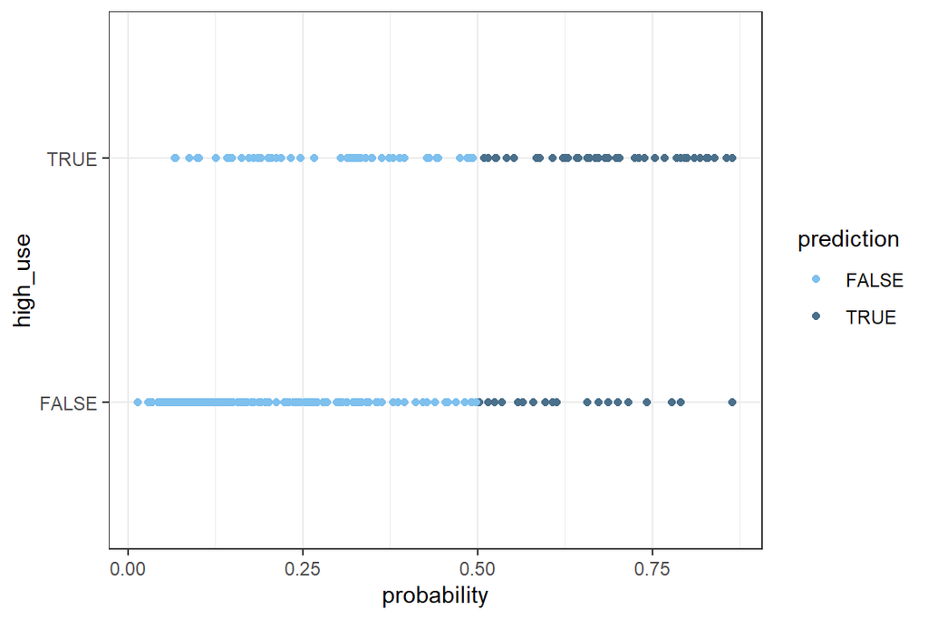

```r
# initialize a plot of 'high_use' versus 'probability' in 'alc'
ggplot(alc, aes(x = probability, y = high_use, col = prediction)) +
  geom_point() +
  scale_color_manual(values = c("skyblue2", "skyblue4"))
```

This model predicts high use incorrectly for 22 students, and low use incorrectly for 63 students.

Next the the total proportion of inaccurately classified individuals, the training error.

```r
# define a loss function (mean prediction error)

loss_func <- function(class, prob) {
  n_wrong <- abs(class - prob) > 0.5
  mean(n_wrong)
}

# call loss_func to compute the average number of wrong predictions in the (training) data
loss_func(class = alc$high_use, prob = alc$probability)
```

```
## [1] 0.2297297
```

The training error is 0.2297, so on average ~23% of the predictions are wrong. The training error is below 0.5, so it is better than randomly guessing.

## Perform 10-fold cross-validation on your model

```r
#K-fold cross-validation, K=10
library(boot)
cv <- cv.glm(data = alc, cost = loss_func, glmfit = model1, K = 10)

# average number of wrong predictions in the cross validation
cv$delta[1]
```

```
## [1] 0.2351351
```